# Kernel PCA

Equipo 3

16 de mayo de 2017

### Metodos Kernel

En ocasiones, es necesario analizar los datos tomando como base una estructura no lineal.

**Definicion** Una funcion $k: X \times X \to \Re$ es funcion Kernell si existe un espacio de Hilbert $F$ y una funcion $\Phi:X \to F$ tal que para toda $x, y \in X$:
$$k(x,y)=\langle\Phi(X). \Phi(Y)\rangle_F$$
Una funcion Kernel es aquella que calcula directamente el producto interior de dos elementos pertenecientes a $X$ en otro espacio $F$ sin necesidad de calcular explicitamente el valor de las entradas en ese otro espacio.

#### Ejemplos de funciones Kernel (clase)

Las funciones kernel nos permiten detectar relaciones no lineales utilizando algoritmos lineales. Si escogemos la funcion kernel apropiada, podemos capturar la estructura no lineal de los datos.

Sea $x,y \in \mathbb{R}^p$:

$\bullet Kernel \quad Lineal$
$$k(x,y)=x^Ty$$

$\bullet Kernel \quad Polinomial$
$$k(x,y)= (ax^Ty+c)^d, \quad d \in \mathbb{Z}, c\geq0, \alpha \neq0$$
$\bullet Kernel \quad Gaussiano$
$$k(x,y)= \exp(-\frac{\|x-y\|^2}{2\sigma^2}), \sigma\neq0$$
Algunos programas reciben el parametro $\gamma= \frac{1}{2\sigma^2}$

$\bullet Kernel \quad Laplaciano$
$$k(x,y)= \exp(-\frac{\|x-y\|}{\sigma}), \sigma\neq0$$
$\bullet Kernel \quad Tangente \quad Hiperbolico$
$$k(x,y)= tanh(\alpha x^Ty+c), \alpha\neq0, c\geq0$$
.

### Funcion Kernel a PCA

Partiendo de un conjunto de datos $X \in \mathbb{R}^{n\times p}$ se aplica una transformacion $\Phi$, y se mapea al espacio $F$

$$\Phi:X \to F$$
Y se trabajara con los elementos
$$\Phi(x_1), \Phi(x_2),\dots,\Phi(x_n)$$

Supongamos que las $\Phi 's$ estan centradas. Entonces la matriz de varianzas y covarianzas $C \in \mathbb{R}^{p\times p}$ de los datos transformados es:
$$C= \frac{1}{n}\sum_{i=1}\Phi(x_i)\Phi(x_i)^T,$$

Ahora, buscaremos obtener los vectores caracteristicos de la matriz de correlaciones. Equivalente a resolver el siguiente sistema:
$$\lambda v=Cv$$

Donde los vectores propios $v$ se pueden expresar como combinacion lineal de $\Phi(x_1), \Phi(x_2),\dots,\Phi(x_n)$, pues
$$\lambda v=Cv = \frac{1}{n}\sum_{i=1}\Phi(x_i)\Phi(x_i)^Tv,$$
entonces,
$$v= \frac{1}{\lambda n}\sum_{i=1}\Phi(x_i)\Phi(x_i)^Tv= \frac{1}{\lambda n}\sum_{i=1}(\Phi(x_i)^Tv)\Phi(x_i),$$
por lo tanto
$$v= \sum_{i=1}\alpha_i \Phi(x_i)$$
Partiendo de $\lambda v=Cv$ se tiene que
$$\lambda \sum_{i=1}\alpha_i (\Phi(x_k).\Phi(x_i))= \frac{1}{n}\sum_{i=1} \alpha_i \bigg(\Phi(x_k).\sum_{j=1}\Phi(x_j) \bigg)(\Phi(x_j).\Phi(x_i))$$
Definiendo la matriz $K \in \mathbb{R}^{nxn}$ como $K_{ij}=(\Phi(x_i).\Phi(x_j))$, lo anterior equivale a
$$n \lambda K \alpha =K^2\alpha,$$
y basta con resolver el problema $n \lambda \alpha = K \alpha$ para valores caracteristicos distintos de cero.

Por lo tanto, $\lambda v=Cv$ se reduce a obtener los vectores propios de la matriz kernel $K$.

Para obtener la componente principal no lineal con respecto a $\Phi$, de un vector $x \in \mathbb{R}^{p}$ con imagen en $F$, se debe calcular su proyeccion en los vectores propios $v_j, (j=1\dots , p)$ de la matriz de varianzas y covarianzas $C$, es decir $(v_j.\Phi(x))$

Usando el truco del Kernel
$$v_j.\Phi(x) = \sum_{i=1}\alpha_j^i (\Phi(x_i).\Phi(x))=\sum_{i=1}\alpha_j^ik(x_i,x)$$
donde $\alpha_j^i$ es el elemento $i (i=1, \dots ,n)$ del j-esimo vector caracteristico de C. Se tiene una condicion de normalizacion para los vectores caracteristicos de $C, v_1, \dots v_n$
$$(v_j.v_j)=1$$
lo cual se traduce en una condicion sobre los vectores $\alpha$, pues:
$$(v_j.v_j)= \sum_{i=1}\alpha_j^i \alpha_j^k (\Phi(x_i).\Phi(x_k))=\alpha_j K \alpha_j = \lambda_j(\alpha_j . \alpha_j)$$

y por lo tanto

$$\lambda_j(\alpha_j . \alpha_j)=1$$
.

## Ejemplo 1, Puntos de Circunferencia

Un primera forma para ilustrar el *Kernel PCA*, es generar puntos aleatorios correspondientes a circunferencias.

Tomamos 3 radios distintos para generar 150 puntos correspondientes a tres diferentes circunferencias. Es decir, generamos 450 puntos.

$$R_1=1 \quad R_2=2.8 \quad R_3=5$$
$$x^2+y^2=R_i + c$$

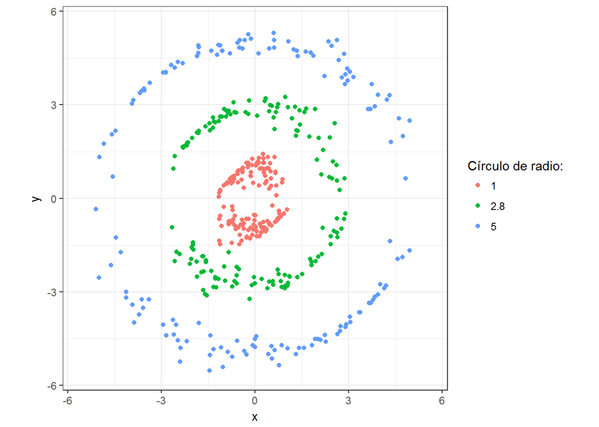

Se realiza Análisis de Componentes Principales basado en kernels cambiando la función kernel utilizada con el objetivo de comparar los resultados.

Necesitamos el paquete `kernlab` y se usa la función `kpca(...)`.

#### Kernel Gaussiano

En las siguientes figuras se muestra KPCA usando la funcion *Kernel Gaussiano* y variando el parametro $\sigma$ tal que,
$$\sigma_1 = 0.2, \quad \sigma_2=0.1,\quad \sigma_3=0.5$$
.

$$k(x,y)= \exp(-\frac{\|x-y\|^2}{2\sigma^2}), \sigma\neq0$$

```r
library(kernlab)
library(magrittr)
library(dplyr)
library(gridExtra)
library(tidyr)
```

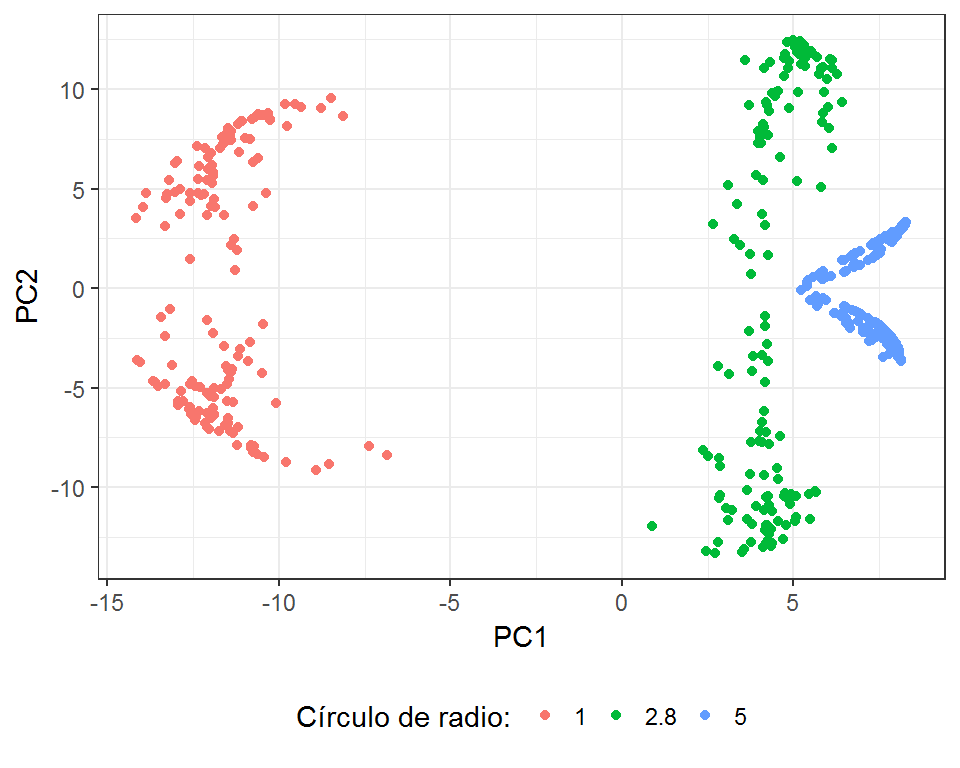

```r
theme_set(theme_bw())
#kernel gaussiano
kpc_gaus <- kpca(~.,
                 data = datos[],
                 kernel="rbfdot",
                 kpar=list(sigma=.2),
                 features=2)
matrix.kpca <- as.data.frame(rotated(kpc_gaus))
matrix.kpca$Z <- datos$z
gg1<-ggplot(matrix.kpca, aes(V1, V2, color = factor(Z))) +
  geom_point() +
  xlab("PC1")+
  ylab("PC2")+
  scale_color_discrete(name="Círculo de radio:")+
  theme(legend.position = "bottom")
gg1
```

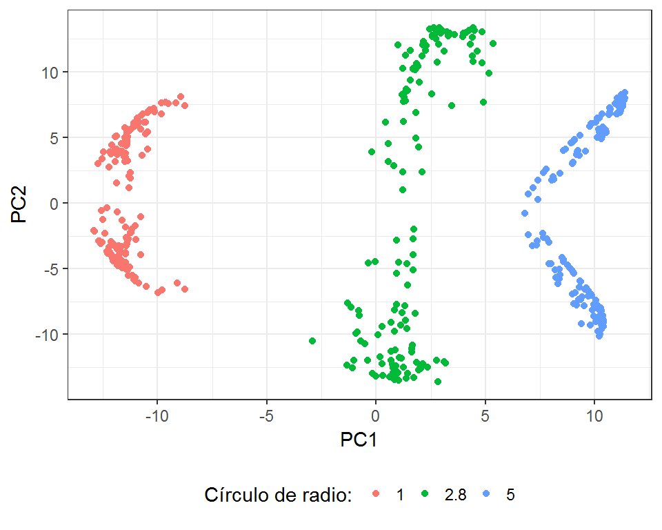

```r
kpc_gaus <- kpca(~.,
                 data = datos,
                 kernel="rbfdot",
                 kpar=list(sigma=.1),
                 features=2)
matrix.kpca <- as.data.frame(rotated(kpc_gaus))
matrix.kpca$Z <- datos$z
gg2<-ggplot(matrix.kpca, aes(V1, V2, color = factor(Z))) +
  geom_point() +
  xlab("PC1")+
  ylab("PC2")+
  scale_color_discrete(name="Círculo de radio:")+
  theme(legend.position = "bottom")
gg2
```

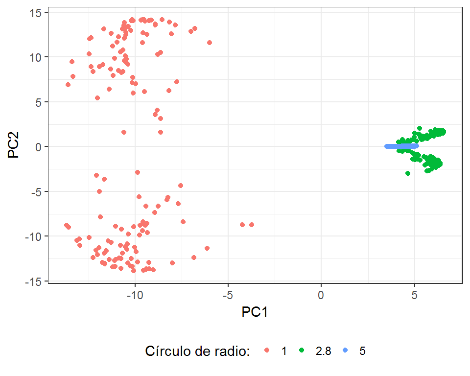

```r
kpc_gaus <- kpca(~.,
                 data = datos,
                 kernel="rbfdot",
                 kpar=list(sigma=.5),
                 features=2)
matrix.kpca <- as.data.frame(rotated(kpc_gaus))
matrix.kpca$Z <- datos$z
gg3<-ggplot(matrix.kpca, aes(V1, V2, color = factor(Z))) +
  geom_point() +
  xlab("PC1")+
  ylab("PC2")+
  scale_color_discrete(name="Círculo de radio:")+
  theme(legend.position = "bottom")
gg3
```

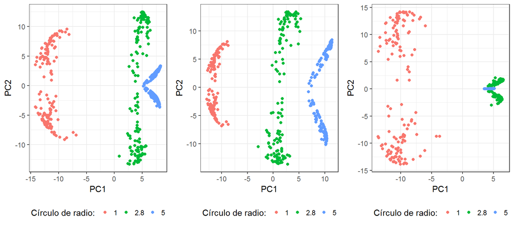

```r
grid.arrange(gg1,gg2,gg3, nrow=1)
```

En las siguientes figuras se muestra KPCA usando la funcion *Kernel Polinomial* de orden 2 y 3.

$$d_1=2, \quad d_2=3$$

$$k(x,y)= (ax^Ty+c)^d, \quad d \in \mathbb{Z}, c\geq0, \alpha \neq0$$

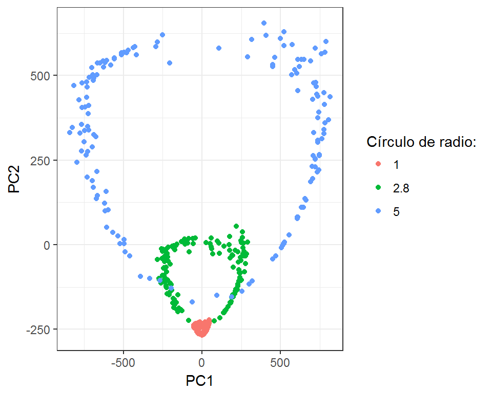

```r
#kernel polinomial
kpc_pol <- kpca(~.,
                 data = datos,
                 kernel="polydot",
                 kpar=list(degree=2),
                 features=2)
matrix.kpca <- as.data.frame(rotated(kpc_pol))
matrix.kpca$Z <- datos$z
ggplot(matrix.kpca, aes(V1, V2, color = factor(Z))) +
  geom_point() +
  xlab("PC1")+
  ylab("PC2")+
  scale_color_discrete(name="Círculo de radio:")
```

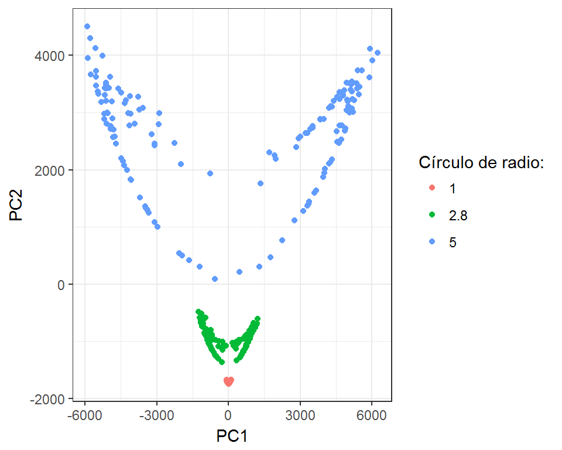

```r
kpc_pol <- kpca(~.,
                 data = datos,
                 kernel="polydot",
                 kpar=list(degree=3),
                 features=2)
matrix.kpca <- as.data.frame(rotated(kpc_pol))
matrix.kpca$Z <- datos$z
ggplot(matrix.kpca, aes(V1, V2, color = factor(Z))) +
  geom_point() +
  xlab("PC1")+
  ylab("PC2")+ scale_color_discrete(name="Círculo de radio:")
```

#### Kernel Tangente

En las siguientes figuras se muestra KPCA usando la funcion *Kernel Tangente Hiperbolico* con $escala$ = $.1$ y dos componentes principales.

$$k(x,y)= tanh(\alpha x^Ty+c), \alpha\neq0, c\geq0$$
.

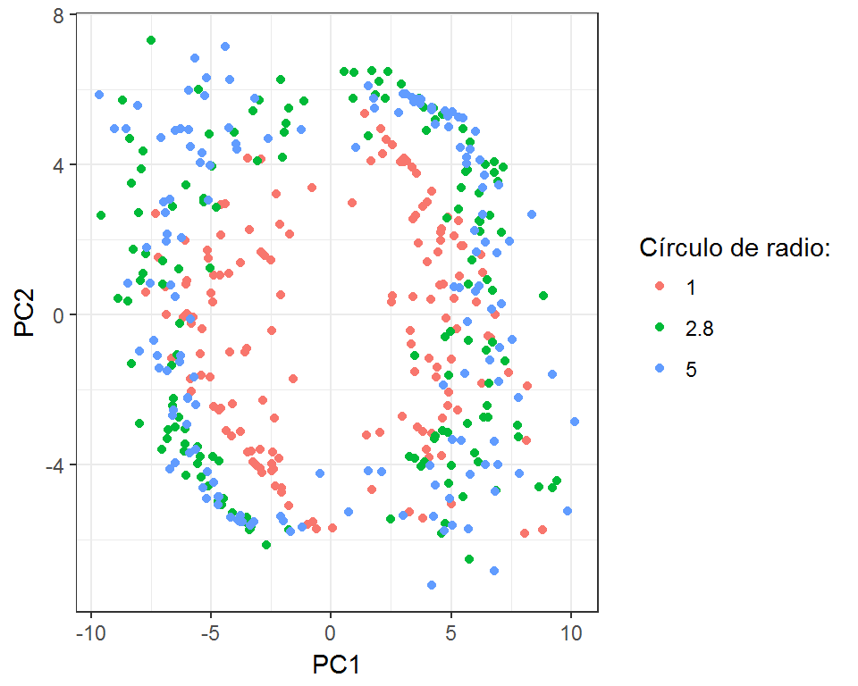

```r
#kernel tangente
kpc_tan <- kpca(~.,
                 data = datos,
                 kernel="tanhdot",
                 kpar =list(scale = .1),
                 features=2)
matrix.kpca <- as.data.frame(rotated(kpc_tan))
matrix.kpca$Z <- datos$z
ggplot(matrix.kpca, aes(V1, V2, color = factor(Z))) +
  geom_point() +
  xlab("PC1")+
  ylab("PC2")+ scale_color_discrete(name="Círculo de radio:")
```

#### Kernel Laplaciano

En las siguientes figuras se muestra KPCA usando la funcion *Kernel Laplace* con parametro $sigma$ = $1$ y dos componentes principales.
$$\sigma=1$$
$$k(x,y)= \exp(-\frac{\|x-y\|}{\sigma}), \sigma\neq0$$

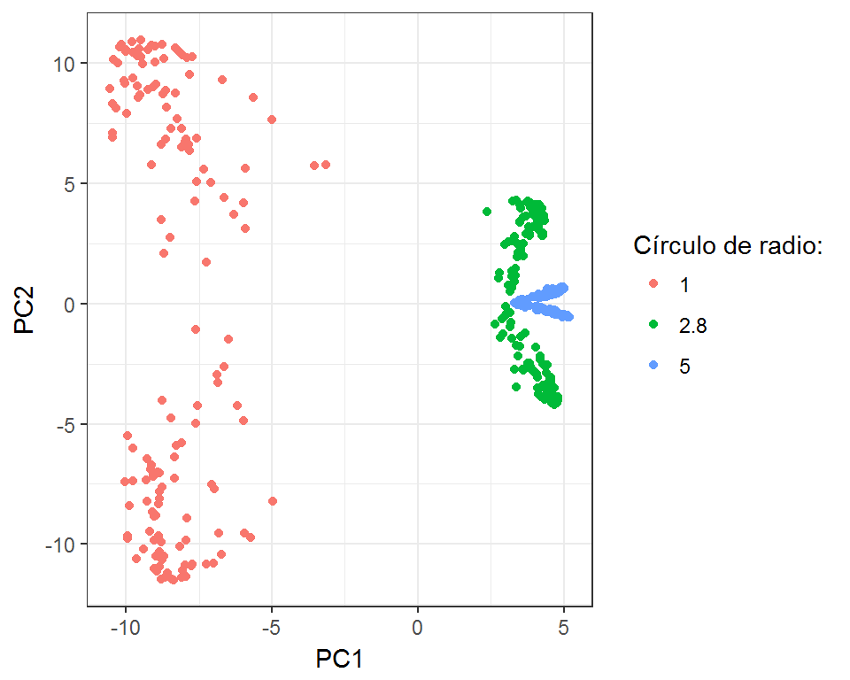

```r
#kernel laplace
kpc_lap <- kpca(~.,
                 data = datos,
                 kernel="laplacedot",
                 kpar=list(sigma=1),
                 features=2)
matrix.kpca <- as.data.frame(rotated(kpc_lap))
matrix.kpca$Z <- datos$z
ggplot(matrix.kpca, aes(V1, V2, color = factor(Z))) +
  geom_point() +
  xlab("PC1")+
  ylab("PC2")+ scale_color_discrete(name="Círculo de radio:")
```

#### Kernel lineal

Y por ultimo, las primeras dos componentes del Kernel Lineal

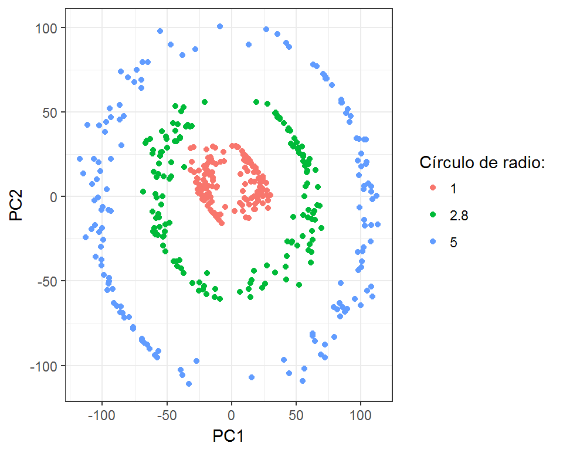

[output not shown]

```r
#kernel lineal
kpc_lap <- kpca(~.,
                 data = datos,
                 kernel="vanilladot",
                  kpar = list(),
                 features=2)
matrix.kpca <- as.data.frame(rotated(kpc_lap))
matrix.kpca$Z <- datos$z
ggplot(matrix.kpca, aes(V1, V2, color = factor(Z))) +
  geom_point() +
  xlab("PC1")+
  ylab("PC2")+ scale_color_discrete(name="Círculo de radio:")
```

## Ejemplo2, Billetes

La base se obtuvo del repositorio de la Universidad de Irvine California (UCI). https://archive.ics.uci.edu/ml/machine-learning-databases/00267/data_banknote_authentication.txt.

Consiste de imágenes de 400 x 400 pixeles de 762 billetes verdaderos y 610 billetes falsificados, a las cuáles se les aplicó una transformación Wavelet para extraer características. En total, se tienen 1372 observaciones con las siguientes 5 variables: -variance, -skewness, -curtosis, -entropy, -class.

```
## # A tibble: 6 × 5
##   variance skewness curtosis  entropy  class
##      <dbl>    <dbl>    <dbl>    <dbl> <fctr>
## 1  3.62160   8.6661  -2.8073 -0.44699      0
## 2  4.54590   8.1674  -2.4586 -1.46210      0
## 3  3.86600  -2.6383   1.9242  0.10645      0
## 4  3.45660   9.5228  -4.0112 -3.59440      0
## 5  0.32924  -4.4552   4.5718 -0.98880      0
## 6  4.36840   9.6718  -3.9606 -3.16250      0
```

```
## [1] 1372    5
```

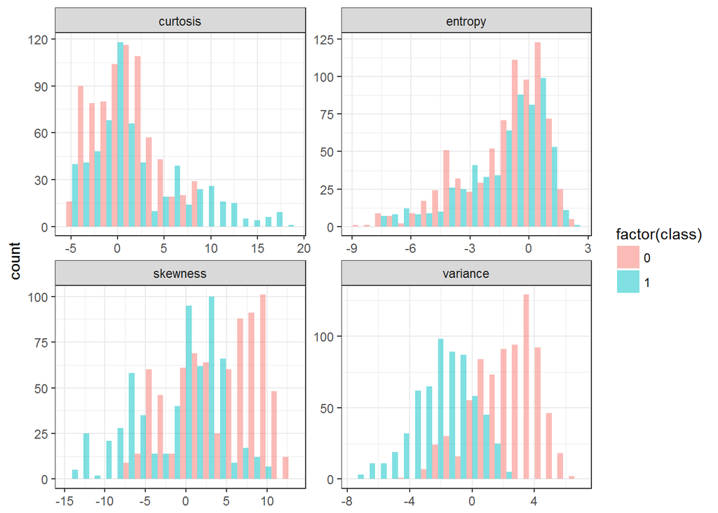

Para el ejercicio, se divide la muestra en dos partes. El 70% de los datos se toma como muestra de entrenamiento y el resto como muestra de prueba. Es importante mencionar que los datos considerados en el ejercicio son centrados.

El objetivo será predecir si un billete es falso considerando las variables anteriores implementando componentes principales y componentes principales con kernel. Es decir, la predicción se realiza con un modelo logístico donde las variables serán las componentes.

### PCA

```
## Importance of components:
##                           PC1    PC2     PC3     PC4
## Standard deviation     7.0870 3.0266 2.09162 1.40382
## Proportion of Variance 0.7641 0.1394 0.06656 0.02998
## Cumulative Proportion  0.7641 0.9035 0.97002 1.00000
```

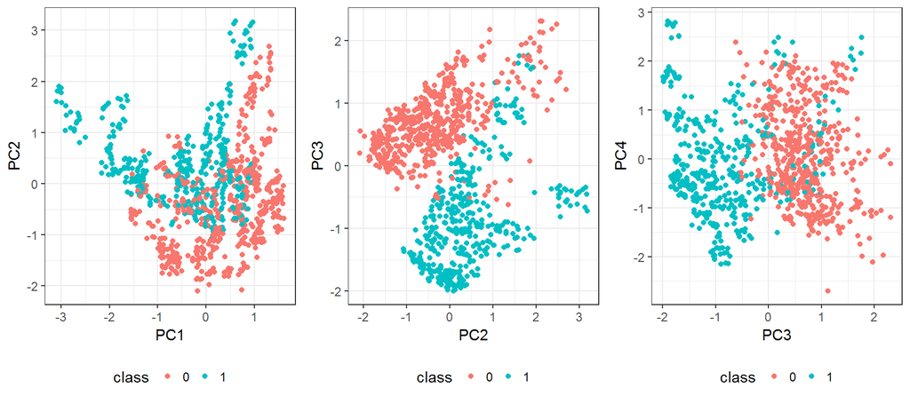

```r
# biplot pca entrenamiento
bip.train <- data.train %>%
  cbind(pca.bank$x %>% scale()) %>%
  as_tibble()
gg.1 <- ggplot(bip.train, aes(x = PC1, y = PC2,
                    color = class)) +
  geom_point() +
  theme(legend.position = "bottom")
gg.2 <- ggplot(bip.train, aes(x = PC2, y = PC3,
                    color = class)) +
  geom_point()+
  theme(legend.position = "bottom")
gg.3 <- ggplot(bip.train, aes(x = PC3, y = PC4,
                    color = class)) +
  geom_point()+
  theme(legend.position = "bottom")
grid.arrange(gg.1, gg.2, gg.3, nrow = 1)
```

### KPCA

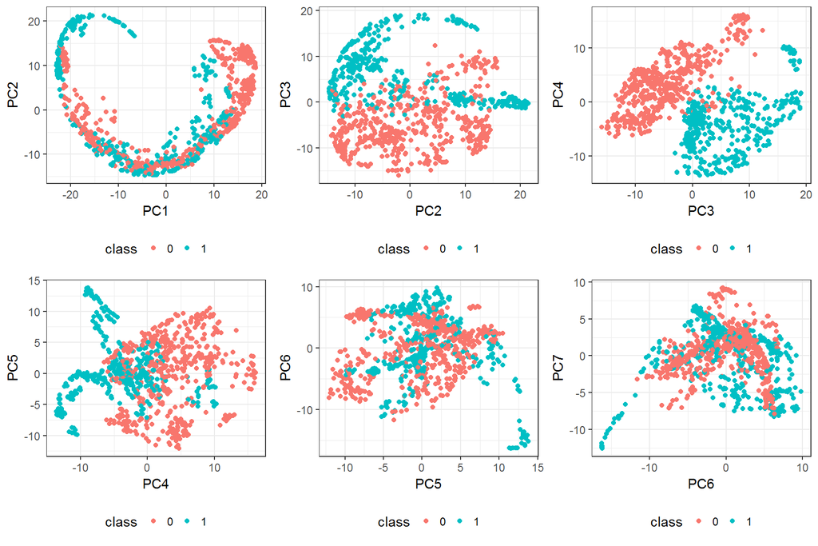

```r
# pca kernel entrenamiento
kpca.bank <- kpca(x =data.train %>%
                    select(ends_with("_c")) %>%  as.matrix,
            kernel = "rbfdot",
            kpar = list(sigma=.01),
            features = 7)

# biplot kpca entrenamiento
kbip.train <- data.train %>%
  cbind(kpca.bank@rotated) %>%
  # cbind( pcv(kpca.bank) ) %>%
  as_tibble()
names(kbip.train)[10:16] <- paste0("PC", 1:7)
gg.1 <- ggplot(kbip.train, aes(x = PC1, y = PC2,
                              color = class)) +
  geom_point() +
  theme(legend.position = "bottom")
gg.2 <- ggplot(kbip.train, aes(x = PC2, y = PC3,
                              color = class)) +
  geom_point()+
  theme(legend.position = "bottom")
gg.3 <- ggplot(kbip.train, aes(x = PC3, y = PC4,
                              color = class)) +
  geom_point()+
  theme(legend.position = "bottom")
gg.4 <- ggplot(kbip.train, aes(x = PC4, y = PC5,
                              color = class)) +
  geom_point() +
  theme(legend.position = "bottom")
gg.5 <- ggplot(kbip.train, aes(x = PC5, y = PC6,
                              color = class)) +
  geom_point()+
  theme(legend.position = "bottom")
gg.6 <- ggplot(kbip.train, aes(x = PC6, y = PC7,
                              color = class)) +
  geom_point()+
  theme(legend.position = "bottom")
grid.arrange(gg.1, gg.2, gg.3, gg.4, gg.5, gg.6, nrow = 2)
```

### Regresión PCA

```r
# ---- #
# regresiones pca
mod.pca <- glm(formula = class ~ PC1 + PC2 + PC3 + PC4 ,
               data = bip.train,
               family = binomial(link = 'logit'))
# entrenamiento
table(predict(mod.pca, type = "response") %>% round,
      bip.train$class)
```

```
##
##       0   1
##   0 545   3
##   1   3 409
```

```r
# prueba
pca.fit.test <- predict(pca.bank, data.test %>% select(ends_with("_c")))
bip.test <- data.test %>%
  cbind(pca.fit.test) %>%
  as_tibble()
tab <- table(bip.test$class,
             round(predict(mod.pca, bip.test, type = "response")))
tab
```

```
##
##       0   1
##   0 197  17
##   1  10 188
```

```r
prop.table(tab, 2) %>% round(2)
```

```
##
##        0    1
##   0 0.95 0.08
##   1 0.05 0.92
```

```r
aciertos <- bip.test$class == round(predict(mod.pca, bip.test, type = "response"))
sum(aciertos)/length(aciertos)
```

```
## [1] 0.934466
```

### Regresiones KPCA

```r
# ----
# regresiones kpca
mod.kpca <- glm(formula = class ~ PC1 + PC2 + PC3 + PC4,
               data = kbip.train,
               family = binomial(link = 'logit'))
# entrenamiento
table(kbip.train$class,
      predict(mod.kpca, type = "response") %>% round)
```

```
##
##       0   1
##   0 544   4
##   1   3 409
```

```r
# prueba
pca.fit.test <- predict(kpca.bank, data.test %>% select(ends_with("_c")))
kbip.test <- data.test %>%
  cbind(pca.fit.test) %>%
  as_tibble()
names(kbip.test)[10:16] <- paste0("PC", 1:7)
```

```r
tab <- table(kbip.test$class,
             round(predict(mod.kpca, kbip.test, type = "response")) )
tab
```

```
##
##       0   1
##   0 212   2
##   1   2 196
```

```r
prop.table(tab, 2) %>%  round(2)
```

```
##
##        0    1
##   0 0.99 0.01
##   1 0.01 0.99
```

```r
aciertos <- kbip.test$class == round(predict(mod.kpca, kbip.test, type = "response"))
sum(aciertos)/length(aciertos)
```

```
## [1] 0.9902913
```

#### Ejemplo 3, digitos

Los datos utilizados provienen de la base de reconocimiento de dígitos escritos a mano del paquete `ElemStatLearn` de R. Ésta consiste en imágenes normalizadas de sobres escaneados del Servicio Postal de Estados Unidos, resultando en imágenes de 16 x 16 pixeles en escalas de grises.

```r
# 0. Librerias
library(kernlab)
library(plyr)
library(dplyr)
library(tidyr)
library(ggplot2)
library(gridExtra)
library(ElemStatLearn)
library(nnet)
```

El objetivo sera agrupar e identificar los digitos dada la eleccion de funciones Kernel. Se comparará el agrupamiento y la identificacion contra PCA simple. ####Preparación de los datos y gráfica dígitos

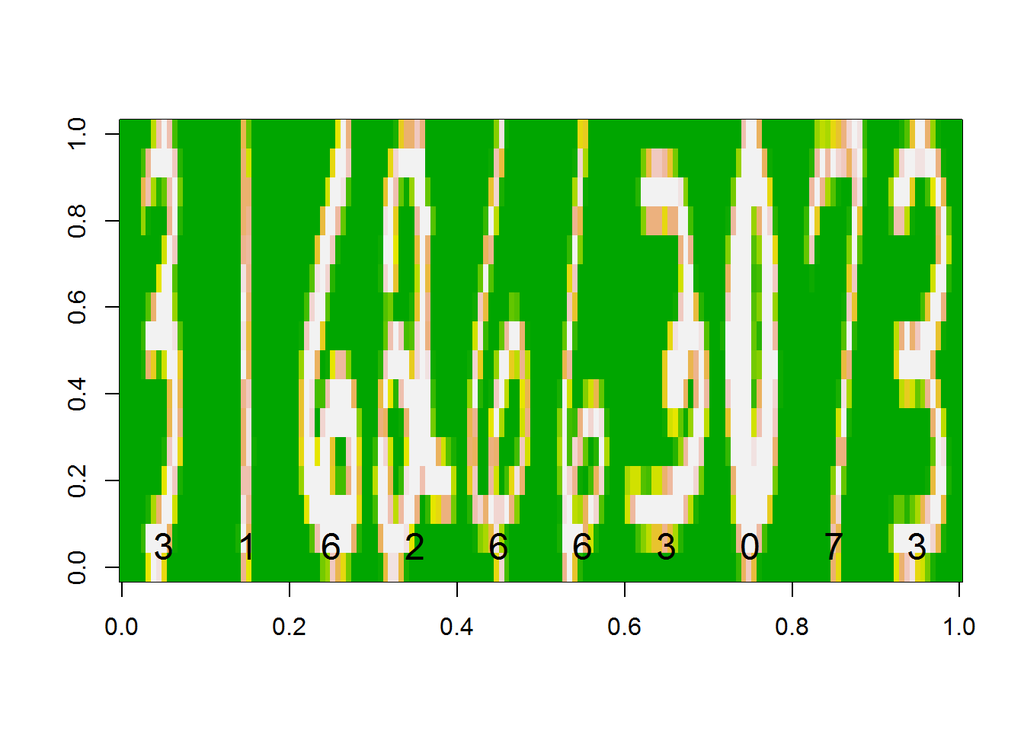

```r
graficar_digitos <- function(datos){
  mat_digitos <- lapply(1:nrow(datos),
                        function(x){
                          t(matrix(as.numeric(datos[x, 2:257]),
                                   16, 16, byrow = T))[,16:1]
                        })
  image (z = Reduce("rbind", mat_digitos), col = terrain.colors(30))
  text(seq(0,1,1/10) + 0.05, 0.05, label = datos[, 1], cex = 1.5)
}


set.seed(160516)
zip_train <- data.frame(zip.train)
zip_test<-data.frame(zip.test)
muestra <- zip_train %>% sample_n(10)
graficar_digitos(muestra)
```

```r
muestra <- sample(1:nrow(zip_train),2000)
muestra_dig <- zip_train[muestra,]
```

#### PCA

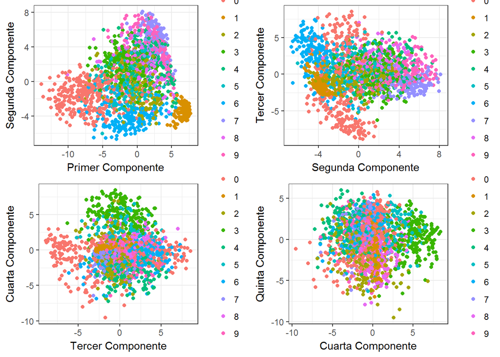

```r
pca <- prcomp(~.,data=muestra_dig[,-1])
matrix_pca<-as.data.frame(pca$x)
matrix_pca$digito <- as.character(muestra_dig$X1)



plot1<-qplot(PC1,PC2,data=matrix_pca,color=factor(digito))+
  xlab("Primer Componente")+ylab("Segunda Componente") + theme(legend.title=element_blank())
plot2<-qplot(PC2,PC3,data=matrix_pca,color=factor(digito))+
  xlab("Segunda Componente")+ylab("Tercer Componente") + theme(legend.title=element_blank())
plot3<-qplot(PC3,PC4,data=matrix_pca,color=factor(digito))+
  xlab("Tercer Componente")+ylab("Cuarta Componente") + theme(legend.title=element_blank())
plot4<-qplot(PC4,PC5,data=matrix_pca,color=factor(digito))+
  xlab("Cuarta Componente")+ylab("Quinta Componente") + theme(legend.title=element_blank())
grid.arrange(plot1, plot2, plot3, plot4)
```

##### Proyección de una submuestra:

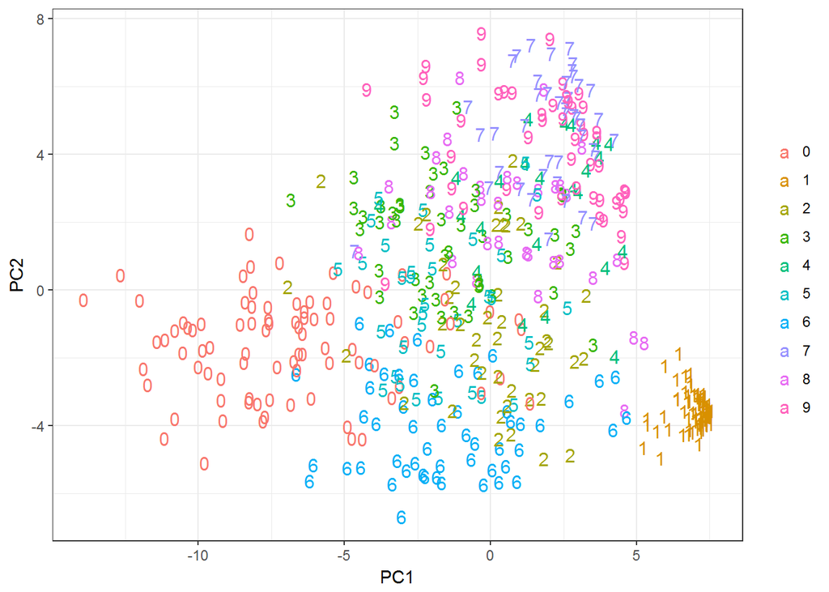

```r
muestra2 <- sample(1:nrow(matrix_pca),500)
matrix_pca2 <- matrix_pca[muestra2,]
ggplot(matrix_pca2, aes(x=PC1, y=PC2, colour=digito, label=digito)) + geom_text(size=4) +
  theme(legend.title=element_blank())
```

##### Proyecciones de las dos primeras componentes separando por dígitos

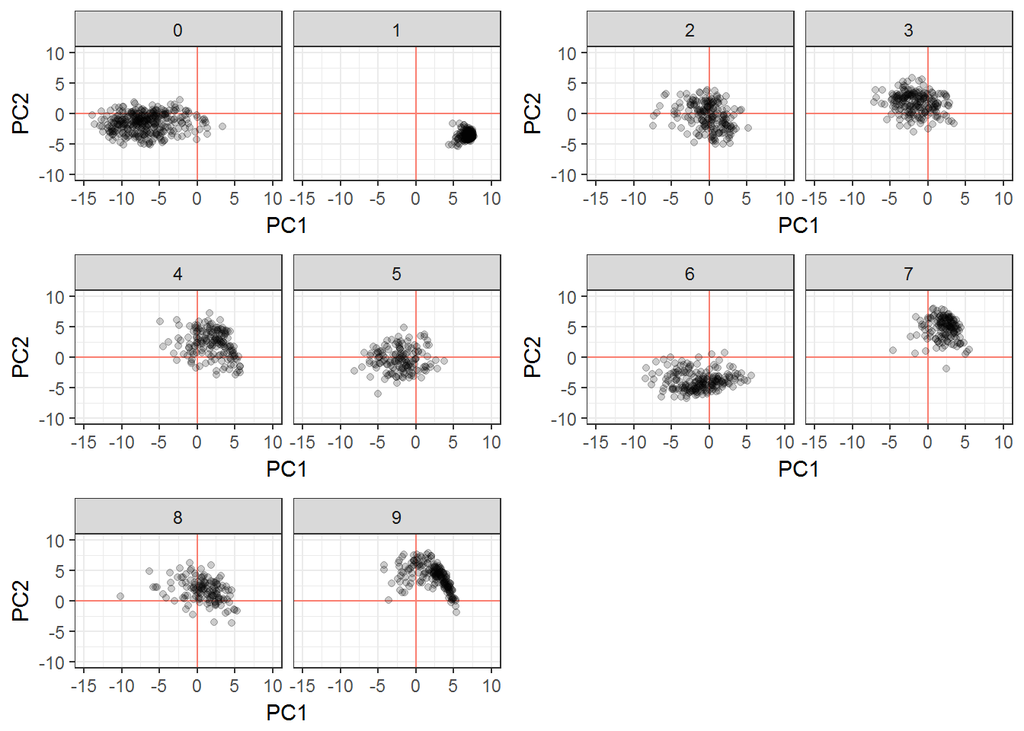

```r
#
dat.comp <- data.frame(pca$x[, 1:2], digito = muestra_dig[, 1])
dat.comp <- subset(dat.comp, digito == 0 | digito == 1)
plotpca1<-ggplot(dat.comp, aes(x = PC1, y = PC2)) +
  facet_wrap(~digito) + geom_vline(xintercept = 0, col ="salmon") +
  geom_hline(yintercept = 0, col="salmon") +
  geom_point(alpha=0.2) +
  scale_x_continuous(limits = c(-15, 10)) +  scale_y_continuous(limits = c(-10, 10))

#
dat.comp <- data.frame(pca$x[, 1:2], digito = muestra_dig[, 1])
dat.comp <- subset(dat.comp, digito == 2 | digito == 3)
plotpca2<-ggplot(dat.comp, aes(x = PC1, y = PC2)) +
  facet_wrap(~digito) + geom_vline(xintercept = 0, col ="salmon") +
  geom_hline(yintercept = 0, col="salmon") +
  geom_point(alpha=0.2) +
  scale_x_continuous(limits = c(-15, 10)) +  scale_y_continuous(limits = c(-10, 10))

#
dat.comp <- data.frame(pca$x[, 1:2], digito = muestra_dig[, 1])
dat.comp <- subset(dat.comp, digito == 4 | digito == 5)
plotpca3<-ggplot(dat.comp, aes(x = PC1, y = PC2)) +
  facet_wrap(~digito) + geom_vline(xintercept = 0, col ="salmon") +
  geom_hline(yintercept = 0, col="salmon") +
  geom_point(alpha=0.2) +
  scale_x_continuous(limits = c(-15, 10)) +  scale_y_continuous(limits = c(-10, 10))

#
dat.comp <- data.frame(pca$x[, 1:2], digito = muestra_dig[, 1])
dat.comp <- subset(dat.comp, digito == 6 | digito == 7)
plotpca4<-ggplot(dat.comp, aes(x = PC1, y = PC2)) +
  facet_wrap(~digito) + geom_vline(xintercept = 0, col ="salmon") +
  geom_hline(yintercept = 0, col="salmon") +
  geom_point(alpha=0.2) +
  scale_x_continuous(limits = c(-15, 10)) +  scale_y_continuous(limits = c(-10, 10))

#
dat.comp <- data.frame(pca$x[, 1:2], digito = muestra_dig[, 1])
dat.comp <- subset(dat.comp, digito == 8 | digito == 9)
plotpca5<-ggplot(dat.comp, aes(x = PC1, y = PC2)) +
  facet_wrap(~digito) + geom_vline(xintercept = 0, col ="salmon") +
  geom_hline(yintercept = 0, col="salmon") +
  geom_point(alpha=0.2) +
  scale_x_continuous(limits = c(-15, 10)) +  scale_y_continuous(limits = c(-10, 10))
grid.arrange(plotpca1, plotpca2, plotpca3, plotpca4, plotpca5)
```

##### Se ajustó una regresión multinomial con las primeras veinte componentes y se estimó el número de dígitos correctamente clasificados

```r
matrix_pca<-as.data.frame(pca$x)

matrix.pca.reg <- cbind(matrix_pca[,1:20],digito=as.character(muestra_dig$X1))

fit.pca <- multinom(digito ~ .,data=matrix.pca.reg)
test.pca <- predict(pca,zip_test[,-1])
pred.pca.reg <- predict(fit.pca, newdata = data.frame(test.pca),
                        type="class") # predicted values

varaux <- rep(0,2007)
test.pca.2 <- as.data.frame(cbind(zip_test[,1],
                                  as.factor(pred.pca.reg),varaux))

test.pca.2$V2 <- test.pca.2$V2 - 1
test.pca.2$varaux <- replace(varaux, which(test.pca.2$V1 != test.pca.2$V2), 1)
tabla<-table(test.pca.2$V1,test.pca.2$V2)

tabla2 <- round(prop.table(table(test.pca.2$V1,test.pca.2$V2),1),4)
pca_accuracy_20<-data.frame(Digito=numeric(), Accuracy=numeric())
for(i in 1:10){
  pca_accuracy_20[i,"Digito"]=as.character(i-1)
  pca_accuracy_20[i,"Accuracy"]=tabla2[i,i]
}


aciertos<-sum(diag(tabla))
total<-sum(tabla[1,], tabla[2,], tabla[3,], tabla[4,], tabla[5,], tabla[6,], tabla[7,], tabla[8,], tabla[9,], tabla[10,])
aciertos_fraction<-aciertos/total

pca_accuracy_20[11,"Accuracy"]<-aciertos_fraction
pca_accuracy_20[11,"Digito"]<-"Global"
pca_accuracy_20
```

```
##    Digito  Accuracy
## 1       0 0.9387000
## 2       1 0.9545000
## 3       2 0.7879000
## 4       3 0.8554000
## 5       4 0.8500000
## 6       5 0.8312000
## 7       6 0.9000000
## 8       7 0.8980000
## 9       8 0.8313000
## 10      9 0.8644000
## 11 Global 0.8799203
```

#### PCA Basado en kernels

Para este método se utilizó un kernel Gaussiano con valor $\gamma=0.01$

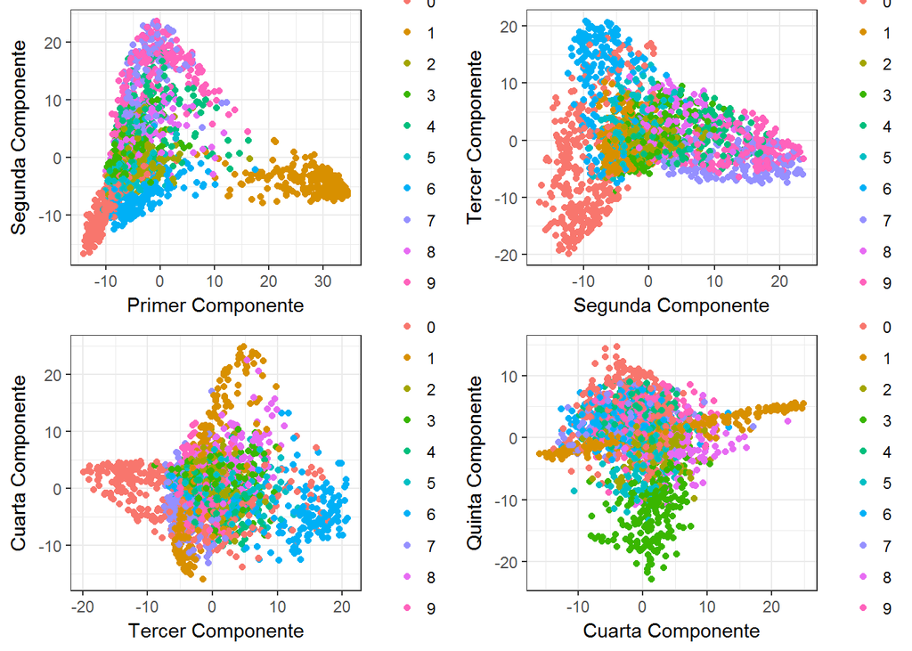

```r
kpc <- kpca(~.,data=muestra_dig[,-1],kernel="rbfdot",
            kpar=list(sigma = .01),features=5)
matrix.kpca<-as.data.frame(rotated(kpc))
matrix.kpca$digito <- as.character(muestra_dig$X1)

kpcplot1<-qplot(V1,V2,data=matrix.kpca,color=factor(digito))+
  xlab("Primer Componente")+ylab("Segunda Componente") + theme(legend.title=element_blank())
kpcplot2<-qplot(V2,V3,data=matrix.kpca,color=factor(digito))+
  xlab("Segunda Componente")+ylab("Tercer Componente") + theme(legend.title=element_blank())
kpcplot3<-qplot(V3,V4,data=matrix.kpca,color=factor(digito))+
  xlab("Tercer Componente")+ylab("Cuarta Componente") + theme(legend.title=element_blank())
kpcplot4<-qplot(V4,V5,data=matrix.kpca,color=factor(digito))+
  xlab("Cuarta Componente")+ylab("Quinta Componente") + theme(legend.title=element_blank())
grid.arrange(kpcplot1, kpcplot2, kpcplot3, kpcplot4)
```

##### Proyección de una submuestra

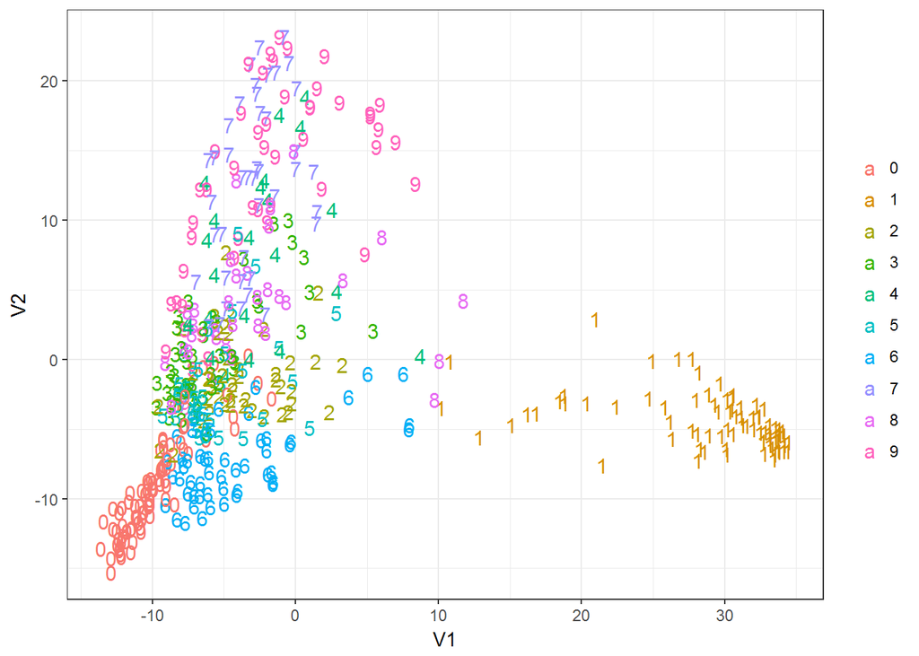

```r
matrix.kpca2 <- matrix.kpca[muestra2,]
ggplot(matrix.kpca2, aes(x=V1, y=V2, colour=digito, label=digito)) + geom_text(size=4) +
  theme(legend.title=element_blank())
```

##### Proyecciones de las dos primeras componentes separando por dígitos

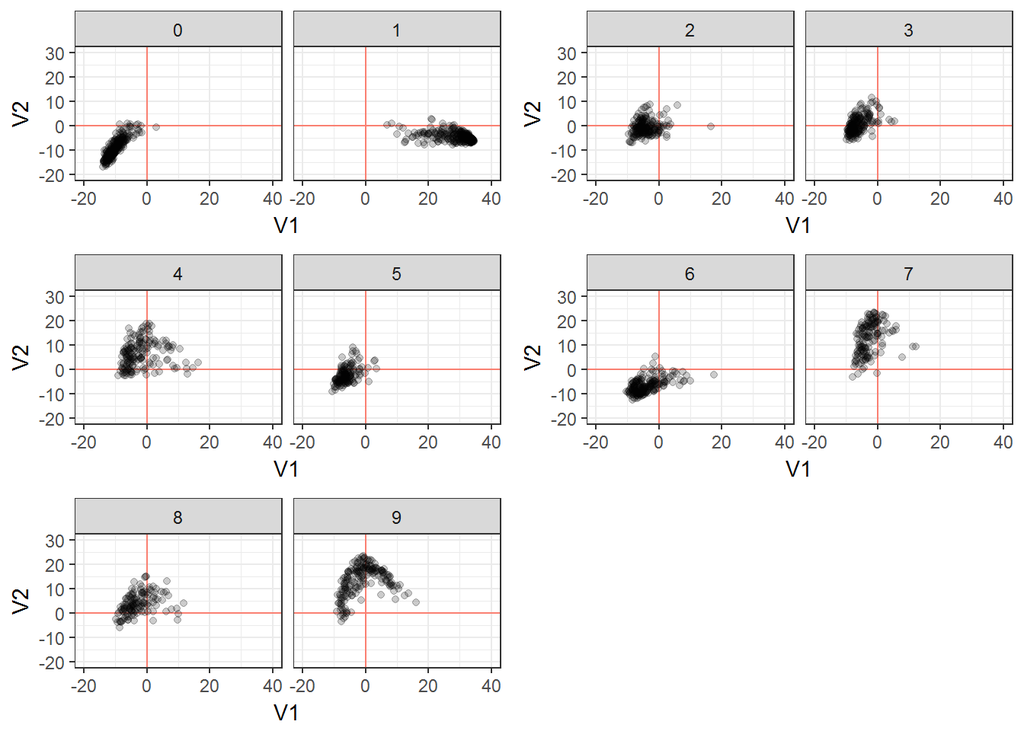

```r
#
dat.kpca <- data.frame(matrix.kpca[, 1:2], digito = muestra_dig[, 1])
dat.kpca <- subset(dat.kpca, digito == 0 | digito == 1)
plotkpca1<-ggplot(dat.kpca, aes(x = V1, y = V2)) +
  facet_wrap(~digito) + geom_vline(xintercept = 0, col ="salmon") +
  geom_hline(yintercept = 0, col="salmon") +
  geom_point(alpha=0.2) +
  scale_x_continuous(limits = c(-20, 40)) +  scale_y_continuous(limits = c(-20, 30))

#
dat.kpca <- data.frame(matrix.kpca[, 1:2], digito = muestra_dig[, 1])
dat.kpca <- subset(dat.kpca, digito == 2 | digito == 3)
plotkpca2<-ggplot(dat.kpca, aes(x = V1, y = V2)) +
  facet_wrap(~digito) + geom_vline(xintercept = 0, col ="salmon") +
  geom_hline(yintercept = 0, col="salmon") +
  geom_point(alpha=0.2) +
  scale_x_continuous(limits = c(-20, 40)) +  scale_y_continuous(limits = c(-20, 30))

#
dat.kpca <- data.frame(matrix.kpca[, 1:2], digito = muestra_dig[, 1])
dat.kpca <- subset(dat.kpca, digito == 4 | digito == 5)
plotkpca3<-ggplot(dat.kpca, aes(x = V1, y = V2)) +
  facet_wrap(~digito) + geom_vline(xintercept = 0, col ="salmon") +
  geom_hline(yintercept = 0, col="salmon") +
  geom_point(alpha=0.2) +
  scale_x_continuous(limits = c(-20, 40)) +  scale_y_continuous(limits = c(-20, 30))

#
dat.kpca <- data.frame(matrix.kpca[, 1:2], digito = muestra_dig[, 1])
dat.kpca <- subset(dat.kpca, digito == 6 | digito == 7)
plotkpca4<-ggplot(dat.kpca, aes(x = V1, y = V2)) +
  facet_wrap(~digito) + geom_vline(xintercept = 0, col ="salmon") +
  geom_hline(yintercept = 0, col="salmon") +
  geom_point(alpha=0.2) +
  scale_x_continuous(limits = c(-20, 40)) +  scale_y_continuous(limits = c(-20, 30))

#
dat.kpca <- data.frame(matrix.kpca[, 1:2], digito = muestra_dig[, 1])
dat.kpca <- subset(dat.kpca, digito == 8 | digito == 9)
plotkpca5<-ggplot(dat.kpca, aes(x = V1, y = V2)) +
  facet_wrap(~digito) + geom_vline(xintercept = 0, col ="salmon") +
  geom_hline(yintercept = 0, col="salmon") +
  geom_point(alpha=0.2) +
  scale_x_continuous(limits = c(-20, 40)) +  scale_y_continuous(limits = c(-20, 30))
grid.arrange(plotkpca1, plotkpca2, plotkpca3, plotkpca4, plotkpca5)
```

##### Tomando las primeras 20 componentas del PCA basado en kernel Gaussiano se hizo una regresión multinomial

```r
kpc <- kpca(~.,data=muestra_dig[,-1],kernel="rbfdot",
            kpar=list(sigma = .01),features=20)

matrix.kpca<-as.data.frame(rotated(kpc))
matrix.kpca$digito <- as.character(muestra_dig$X1)

matrix.kpca.reg <- cbind(matrix.kpca[,1:20],digito=matrix.kpca$digito)

fit.kpca <- multinom(digito ~ .,data=matrix.kpca.reg)
test.kpca <- as.data.frame(predict(kpc,zip_test[,-1]))
names(test.kpca) <- c("V1","V2","V3","V4","V5","V6","V7","V8","V9","V10",
                      "V11","V12","V13","V14","V15","V16","V17","V18","V19","V20")
pred.kpca.reg <- predict(fit.kpca, newdata = data.frame(test.kpca),
                         type="class") # predicted values


varaux2 <- rep(0,2007)
test.kpca.2 <- as.data.frame(cbind(zip_test[,1],
                                   as.factor(pred.kpca.reg),varaux2))

test.kpca.2$V2 <- test.kpca.2$V2 - 1

test.kpca.2$varaux2 <- replace(varaux2, which(test.kpca.2$V1 != test.kpca.2$V2), 1)


tablakpca<-table(test.kpca.2$V1,test.kpca.2$V2)
#renglones reales, columnas estimadas
tablakpca2 <- round(prop.table(table(test.kpca.2$V1,test.kpca.2$V2),1),4)
kpca_accuracy<-data.frame(Digito=numeric(), Accuracy=numeric())

for(i in 1:10){
  kpca_accuracy[i,"Digito"]=as.character(i-1)
  kpca_accuracy[i, "Accuracy"]=(tablakpca2[i,i])
}

aciertoskpca<-sum(diag(tablakpca))
aciertos_fractionkpca<-aciertoskpca/total

kpca_accuracy[11,"Accuracy"]<-aciertos_fractionkpca
kpca_accuracy[11,"Digito"]<-"Global"
kpca_accuracy
```

```
##    Digito  Accuracy
## 1       0 0.9526000
## 2       1 0.9508000
## 3       2 0.8384000
## 4       3 0.8494000
## 5       4 0.8250000
## 6       5 0.8750000
## 7       6 0.8882000
## 8       7 0.8980000
## 9       8 0.8313000
## 10      9 0.8701000
## 11 Global 0.8868959
```

### Referencias

**[1] Principal Component Analysis, Jolliffe, I.T., Springer 2002**

**[2] Análisis de Componentes Principales Basado en Kernels, Zayil, IG, 2016**